# R Course: Data manipulation and plotting

## 3. Plot data

A very useful package **ggplot2** to build your graph step by step with three components: a data set, a coordinate system, and geoms (visual marks that represent data points).  
geoms:  
- scatter plots (geom_point)  
- bar plots (geom_bar)  
- box plots (geom_boxplot)  
Much more options offered by ggplot2 (ggplot cheat sheet)

### Scatter plots

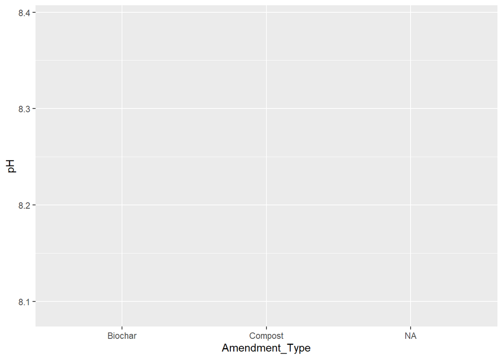

```r
library(ggplot2)
# plot pH

# a data set + coordinate
ggplot(Exp, aes(x=Amendment_Type, y=pH))
```

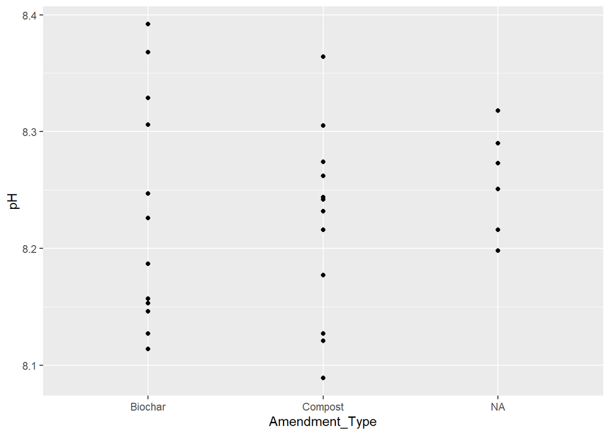

```r
# add the third components geom
ggplot(Exp, aes(x=Amendment_Type, y=pH)) +
  geom_point()
```

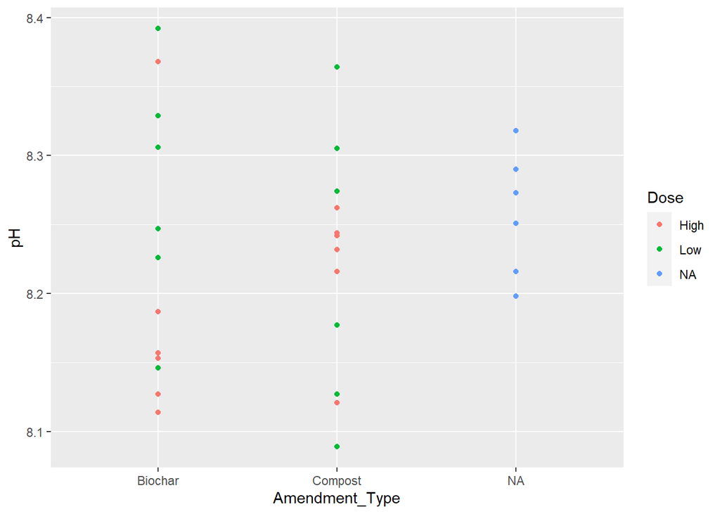

```r
# adjust the aesthetics
ggplot(Exp, aes(x=Amendment_Type, y=pH)) +
  geom_point(aes(color=Dose))
```

```r
# check the types of the column (character, numeric, factor...)
class(Exp$Dose)
```

```
## [1] "character"
```

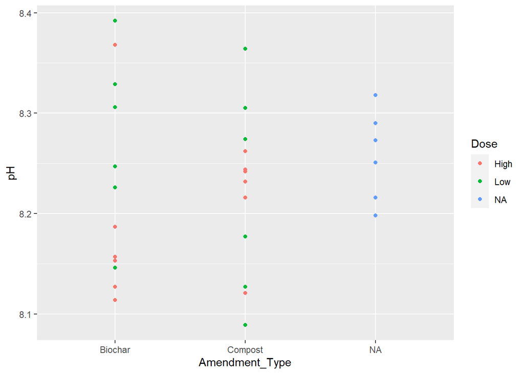

```r
Exp$Dose <- as.factor(Exp$Dose)
ggplot(Exp, aes(x=Amendment_Type, y=pH)) +
  geom_point(aes(color=Dose))
```

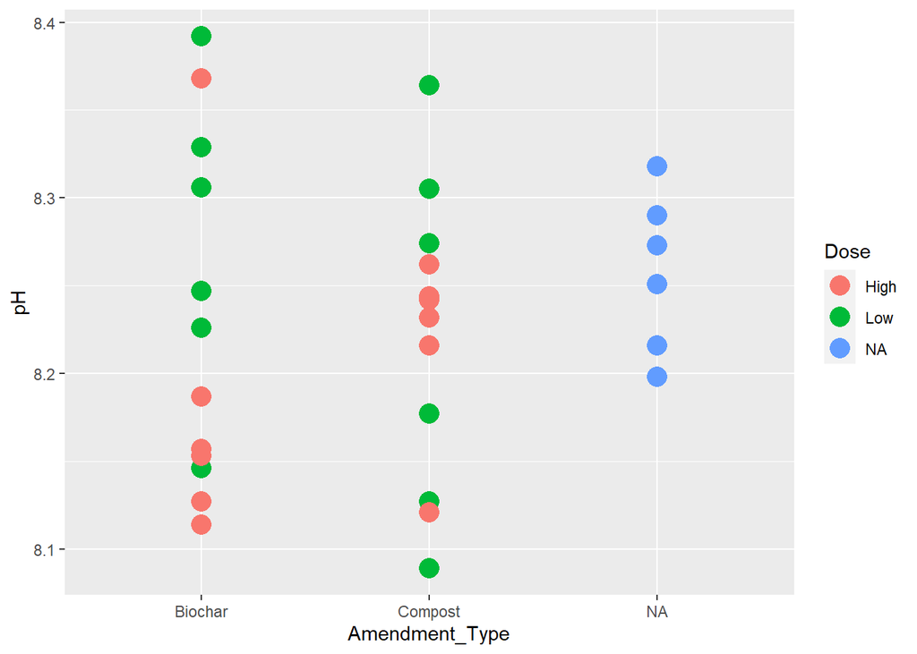

```r
ggplot(Exp, aes(x=Amendment_Type, y=pH)) +
  geom_point(aes(color=Dose), size=5, alpha=1)
```

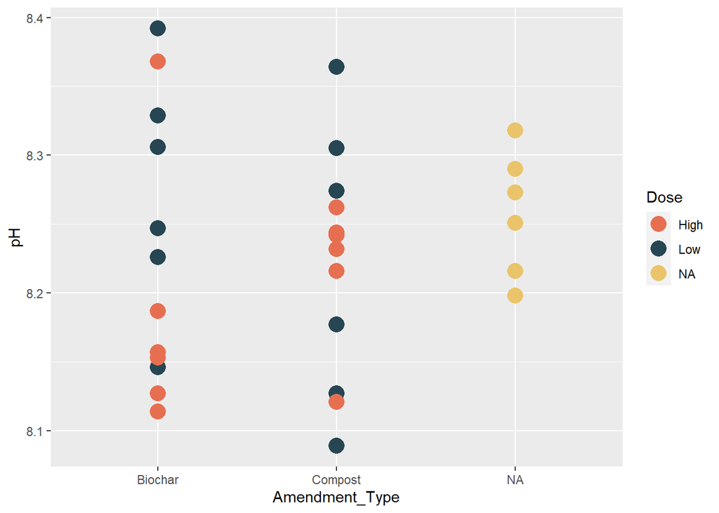

```r
# change color
ggplot(Exp, aes(x=Amendment_Type, y=pH)) +
  geom_point(aes(color=Dose), size=5, alpha=1) +
  scale_color_manual(values=c("#e76f51","#264653","#e9c46a"))
```

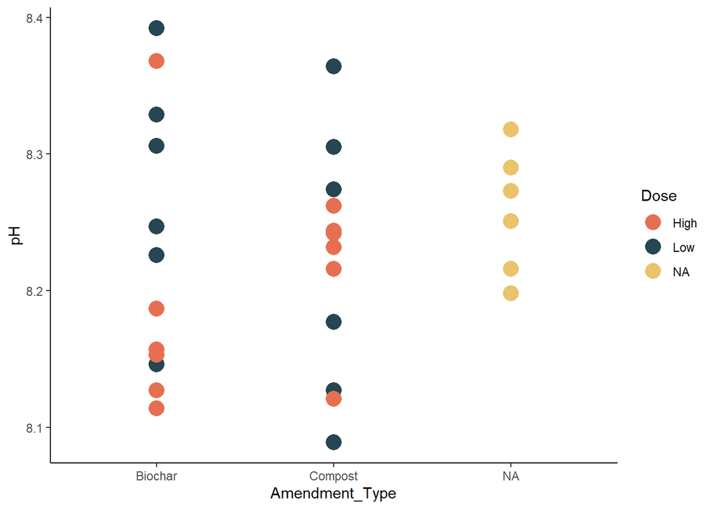

```r
# adjust the theme background
ggplot(Exp, aes(x=Amendment_Type, y=pH)) +
  geom_point(aes(color=Dose), size=5, alpha=1) +
  scale_color_manual(values=c("#e76f51","#264653","#e9c46a"))  +
  theme_classic()
```

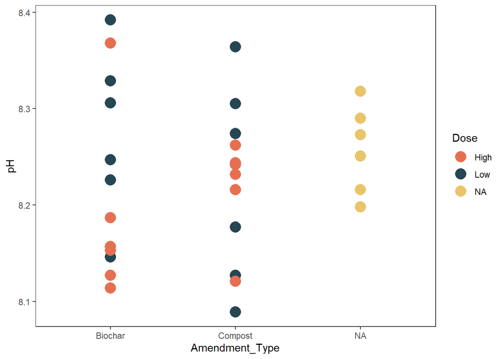

```r
ggplot(Exp, aes(x=Amendment_Type, y=pH)) +
  geom_point(aes(color=Dose), size=5, alpha=1) +
  scale_color_manual(values=c("#e76f51","#264653","#e9c46a")) +
  theme_bw() +
  theme(panel.grid.major = element_blank(),
        panel.grid.minor = element_blank())
```

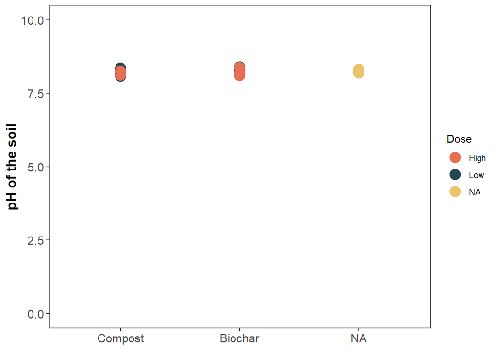

```r
Exp$Amendment_Type <- as.factor(Exp$Amendment_Type)
Exp$Amendment_Type <- factor(Exp$Amendment_Type, levels=c("No", "Compost","Biochar"))
# change x,y axis, and size
ggplot(Exp, aes(x=Amendment_Type, y=pH)) +
  geom_point(aes(color=Dose), size=5, alpha=1) +
  scale_color_manual(values=c("#e76f51","#264653","#e9c46a")) +
  theme_bw() +
  theme(panel.grid.major = element_blank(),
        panel.grid.minor = element_blank()) +
  labs(y = "pH of the soil", x = element_blank()) +
  theme(axis.text=element_text(size=12),
        axis.title=element_text(size=14,face="bold")) +
  ylim(0,10)
```

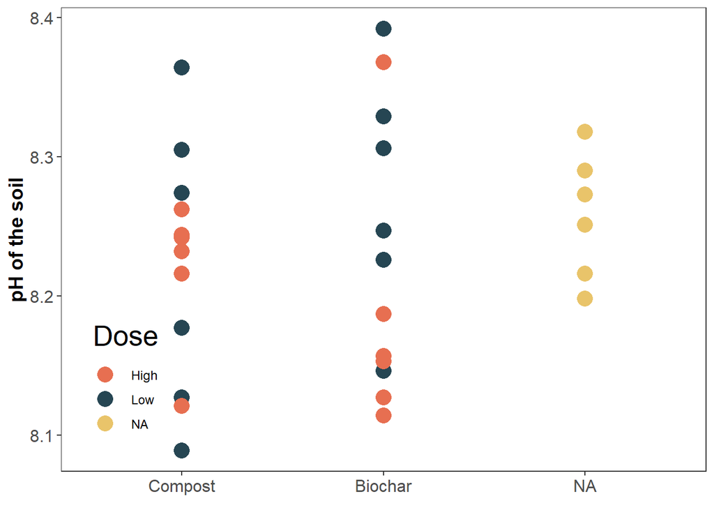

```r
# change legend
ggplot(Exp, aes(x=Amendment_Type, y=pH)) +
  geom_point(aes(color=Dose), alpha=1, size=5) +
  scale_color_manual(values=c("#e76f51","#264653","#e9c46a")) +
  theme_bw() +
  theme(panel.grid.major = element_blank(),
        panel.grid.minor = element_blank()) +
  labs(y = "pH of the soil", x = element_blank()) +
  theme(axis.text=element_text(size=12),
        axis.title=element_text(size=14,face="bold")) +
  theme(legend.position=c(0.1,0.2),
        legend.direction = "vertical",
        legend.title=element_text(size=20),
        legend.text=element_text(size=9))
```

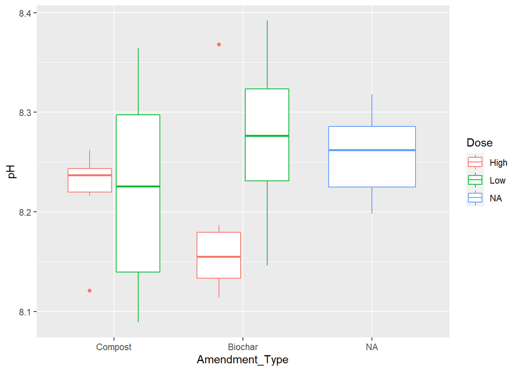

```r
# box plots
ggplot(Exp, aes(x=Amendment_Type, y=pH, color=Dose)) +
  geom_boxplot()
```

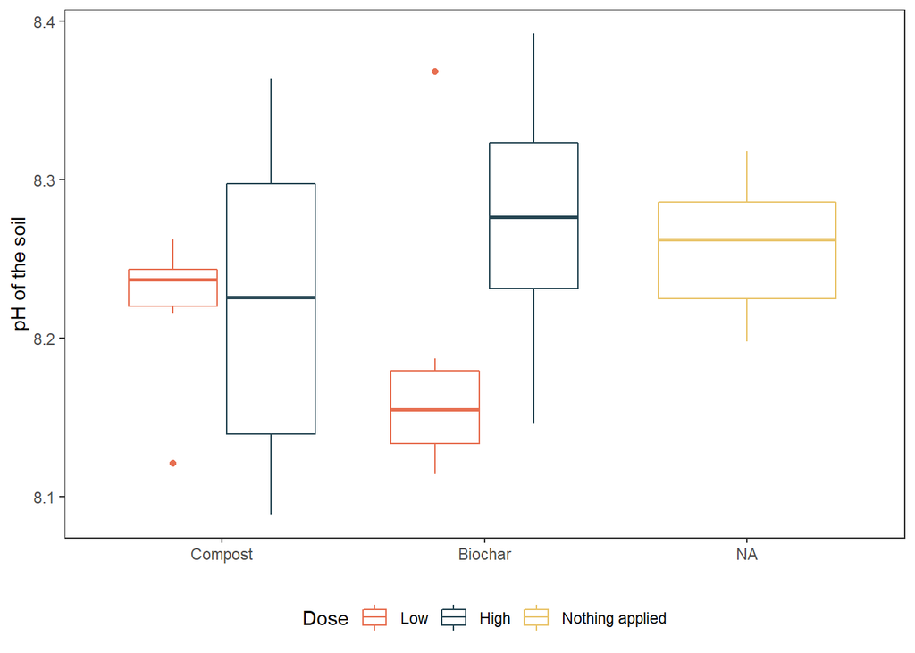

```r
ggplot(Exp, aes(x=Amendment_Type, y=pH, color=Dose)) +
  geom_boxplot() +
  labs(y = "pH of the soil", x = element_blank()) +
  theme_bw() +
  theme(panel.grid.major = element_blank(),
        panel.grid.minor = element_blank()) +
  theme(legend.position="bottom",
        legend.direction = "horizontal") +
  scale_color_manual(name = "Dose", labels = c("Low", "High", "Nothing applied"),
                    values=c("#e76f51","#264653","#e9c46a"))
```

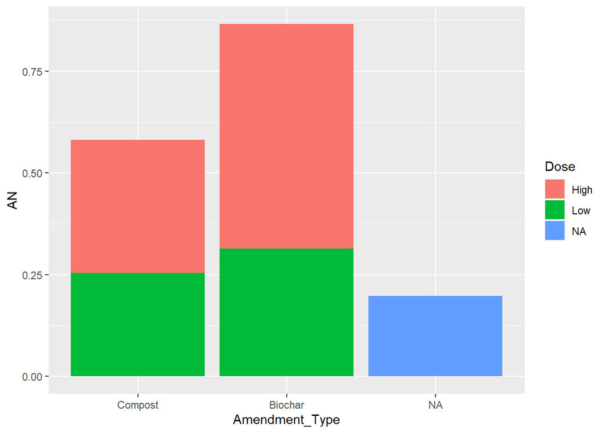

```r
# bar plot
ggplot(Exp, aes(x=Amendment_Type, y=AN, fill=Dose)) +
  geom_bar(stat="identity")
```

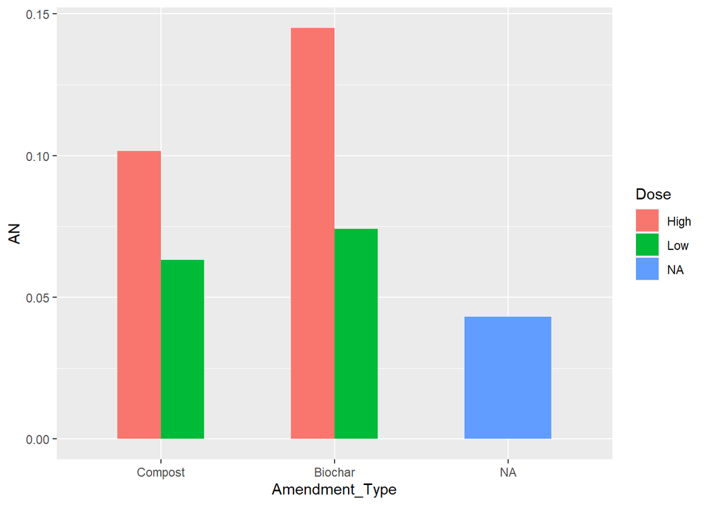

```r
ggplot(Exp, aes(x=Amendment_Type, y=AN, fill=Dose)) +
  geom_bar(stat="identity", position="dodge", width=0.5)
```

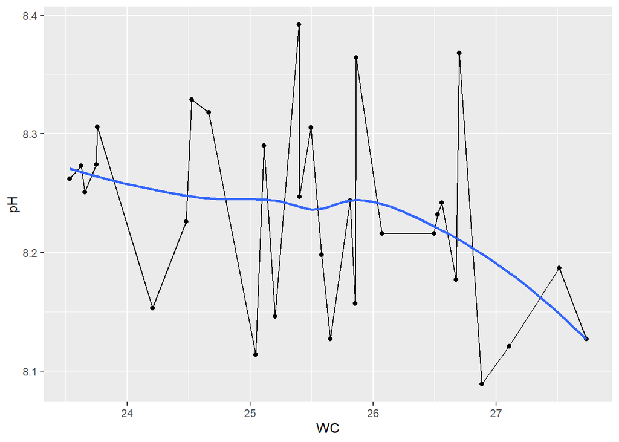

```r
# By default geom_bar() uses stat_count() to plot the frequency of cases at each level of x (some grouping variable)

ggplot(Exp, aes(x=WC, y=pH)) +
  geom_point() +
  geom_line() +
  stat_smooth(se = FALSE)
```

```r
# https://coolors.co/ for color selection and generation
```

### Note:

- Spaces in commands do NOT matter
- CAPITALIZATION does matter
- TRUE and FALSE are logical constants, you can also use abbreviations T and F
- Both single-quotes ’ ’ and double-quotes ” ” symbols are valid
- args(functionName) will show the arguments for functionName with default values

```r
args(read.table)
```

```
## function (file, header = FALSE, sep = "", quote = "\"'", dec = ".",
##     numerals = c("allow.loss", "warn.loss", "no.loss"), row.names,
##     col.names, as.is = !stringsAsFactors, na.strings = "NA",
##     colClasses = NA, nrows = -1, skip = 0, check.names = TRUE,
##     fill = !blank.lines.skip, strip.white = FALSE, blank.lines.skip = TRUE,
##     comment.char = "#", allowEscapes = FALSE, flush = FALSE,
##     stringsAsFactors = default.stringsAsFactors(), fileEncoding = "",
##     encoding = "unknown", text, skipNul = FALSE)
## NULL
```

### Missing values

If there are missing values NA:  
- NA’s will be carried through in computations  
- Operations on NA will always return NA as the result

```r
Result <- IC$Result
Result
```

```
##  [1] 0.37 0.38 0.37   NA   NA   NA   NA   NA   NA   NA   NA   NA   NA   NA   NA
## [16]   NA   NA   NA 0.33 0.36 0.35 0.32 0.29 0.32 0.40 0.38 0.41
```

```r
mean(Result)
```

```
## [1] NA
```

```r
mean(Result, na.rm = TRUE)
```

```
## [1] 0.3566667
```